# Auto Insurance Analysis

### *Categorical variables Visualization*

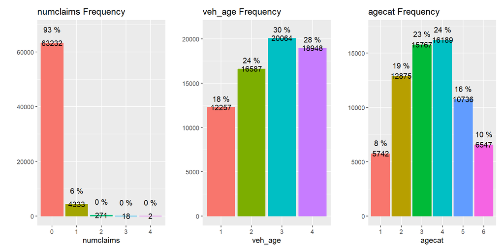

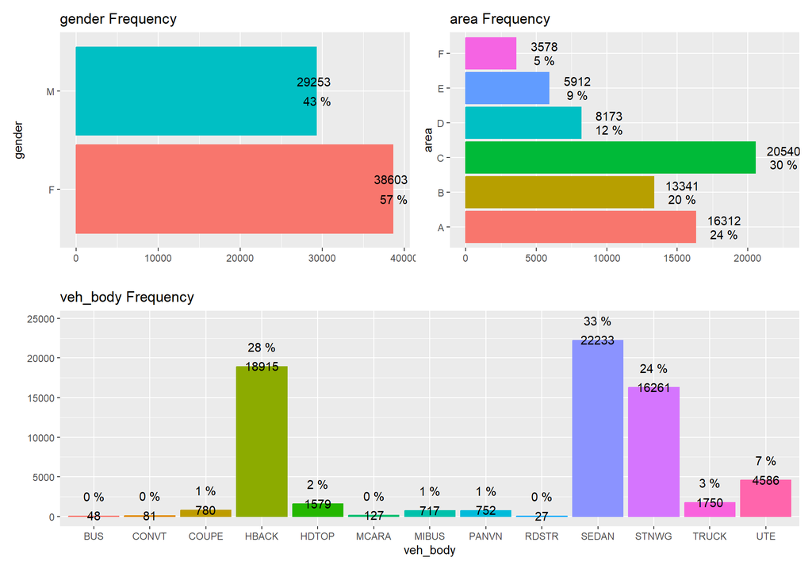

### *Categorical variables in terms of claims occurrence:*

#### *1. gender :*

| **Characteristic** | **N** | **Overall**, N = 67,856<sup>1</sup> | **0**, N = 63,232<sup>1</sup> | **1**, N = 4,624<sup>1</sup> | **p-value**<sup>2</sup> |
| --- | --- | --- | --- | --- | --- |
| gender | 67,856 |  |  |  | 0.6 |
| F |  | 38,603 (57%) | 35,955 (57%) | 2,648 (57%) |  |
| M |  | 29,253 (43%) | 27,277 (43%) | 1,976 (43%) |  |

<sup>1</sup> n (%)  
<sup>2</sup> Pearson’s Chi-squared test

- *Insights*

*A. Out of 67856 risk , we have 4624 with positive claims claims*

*B. female had more claim percentage than males*

*C. the p value of the the pearson chisq test is 0.6 ==> more than 0.05 which statistically means there is no significant difference between genders in respect of claims*

- *Visualizing gender against clm*

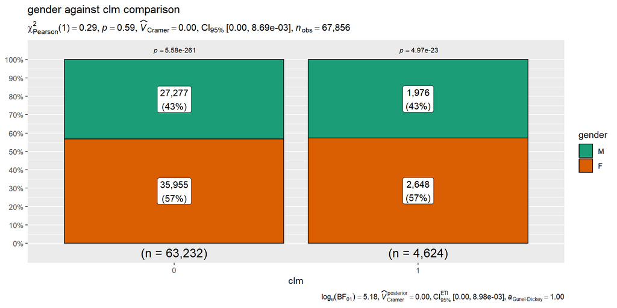

*now we want to assess and report the effect size and the magnitude of differences between these groups*

```r
table <- table(data$clm ,data$gender)
chi_square_test<-chisq.test(table)
phi_coefficient <- sqrt(chi_square_test$statistic / sum(table))
cat(paste("The effect size (Phi Coefficient) is",phi_coefficient ,"indicating",interpret_phi(phi_coefficient),"effect size"))
```

```
## The effect size (Phi Coefficient) is 0.0019987264321987 indicating tiny effect size
```

- *claims probabilities by gender*

```
##  gender   prob      SE  df asymp.LCL asymp.UCL null  z.ratio p.value
##  F      0.0686 0.00129 Inf    0.0661    0.0712  0.5 -129.543  <.0001
##  M      0.0675 0.00147 Inf    0.0647    0.0705  0.5 -112.676  <.0001
##
## Confidence level used: 0.95
## Intervals are back-transformed from the logit scale
## Tests are performed on the logit scale
```

- *Insights*

*the probability of females having claims is little higher than the probability of males with .0686 females and 0.0675 for males*

- *To visualize our results :*

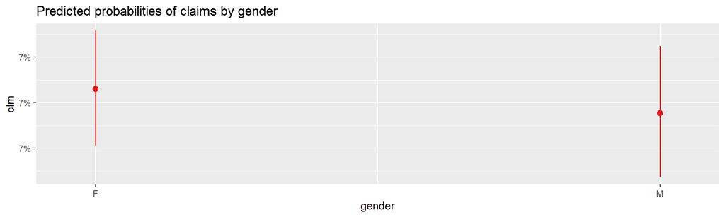